# Quantitative Finance Model using Donadio and Ghosh Learn Algorithmic Trading Chapter 4 Pairs Correlation Trading Example

### August 25, 2022

NOTE: This script is for learning purposes only and does not constitute a recommendation for buying or selling any stock mentioned in this script.

SUMMARY: This project aims to construct and test an algorithmic trading model and document the end-to-end steps using a template.

INTRODUCTION: This script aims to replicate the Pairs Correlation Trading example found in chapter four of the book Learn Algorithmic Trading by Sebastien Donadio and Sourav Ghosh. The script seeks to validate the Python environment and package requirements for running these code examples successfully. The eventual goal is to integrate various example code segments from the book into an end-to-end algorithmic trading system.

Dataset ML Model: Time series analysis with numerical attributes

Source and Further Discussion of the Code Examples: https://github.com/PacktPublishing/Learn-Algorithmic-Trading

# Task 1 - Prepare Environment

## 1.a) Load the required packages and modules

```python
import numpy as np
import pandas as pd
from datetime import date
from statsmodels.tsa.stattools import coint
import matplotlib.pyplot as plt
from pandas_datareader import data
```

## 1.b) Set up the controlling parameters and functions

```python
# Specify the key modeling parameters below
DATA_STORE = '../sharadar.h5'
symbolsIds = ['SPY','AAPL','ADBE','LUV','MSFT','SKYW','QCOM','HPQ','JNPR','AMD','IBM']
Symbol1 = 'MSFT'
Symbol2 = 'JNPR'

MODEL_START_DATE = date(2001, 1, 1)
print("Starting date for the model:", MODEL_START_DATE)

# MODEL_END_DATE = datetime.now().date()
MODEL_END_DATE = date(2017, 12, 31)
print("Ending date for the model:", MODEL_END_DATE)

# Set Pandas dsiplay parameters
pd.set_option('display.max_rows', 500)
pd.set_option('display.max_columns', 500)
pd.set_option('display.width', 1000)
```

```
Starting date for the model: 2001-01-01
Ending date for the model: 2017-12-31
```

# Task 2 - Acquire and Pre-Process Data

```python
def load_financial_data(symbols, start_date, end_date, output_file):
    try:
        df = pd.read_pickle(output_file)
        print('File data found...reading symbols data')
    except FileNotFoundError:
        print('File not found...downloading the symbols data')
        df = data.DataReader(symbols, 'yahoo', start_date, end_date)
        df.to_pickle(output_file)
    return df
```

```python
data = load_financial_data(symbolsIds, start_date=MODEL_START_DATE,
                    end_date = MODEL_END_DATE,
                    output_file='multi_data_large.pkl')
print(data.head())
```

```
File data found...reading symbols data
Attributes  Adj Close                                                                                                                   Close                                                                                                               High                                            …
Symbols           SPY      AAPL       ADBE        LUV       MSFT       SKYW       QCOM        HPQ        JNPR      AMD        IBM         SPY      AAPL       ADBE        LUV      MSFT     SKYW      QCOM        HPQ        JNPR      AMD        IBM        SPY      AAPL     ADBE        LUV     MSFT     …
Date
2001-01-02  86.045502  0.226799  23.221338  20.411095  13.631791  23.294525  23.780750   8.945478   85.009377  14.3750  47.613968  128.812500  0.265625  23.367188  22.306667  21.68750  27.5000  35.43750  13.737511  102.562500  14.3750  81.082695  132.15625  0.272321  29.2500  22.400000  22.5000  29.…
2001-01-03  90.178719  0.249670  28.787941  20.045082  15.065678  24.406305  28.205557  10.072906  109.408745  16.2500  53.122734  135.000000  0.292411  28.968750  21.906668  23.96875  28.8125  42.03125  15.468892  132.000000  16.2500  90.463669  136.00000  0.297991  30.0625  22.000000  24.4375  29.…
2001-01-04  89.208038  0.260152  26.707256  21.198008  15.222814  23.241579  26.485966  10.239250  103.865799  16.6875  52.315735  133.546875  0.304688  26.875000  23.166668  24.21875  27.4375  39.46875  15.724342  125.312500  16.6875  89.089386  135.46875  0.330357  29.3750  23.166668  25.2500  29.…
2001-01-05  86.295998  0.249670  25.589275  21.289516  15.438879  23.506298  24.514719   9.056376   91.018539  16.0000  52.771866  129.187500  0.292411  25.750000  23.266666  24.56250  27.7500  36.53125  13.907811  109.812500  16.0000  89.866158  133.62500  0.310268  27.5000  23.273333  24.9375  27.…
2001-01-08  86.964012  0.252528  24.626575  20.740499  15.379952  22.765104  26.129459   9.278166   95.719719  16.1875  52.526241  130.187500  0.295759  24.781250  22.666668  24.46875  26.8750  38.93750  14.248411  115.484375  16.1875  89.447899  130.18750  0.303292  25.7500  23.320000  24.8750  28.…
```

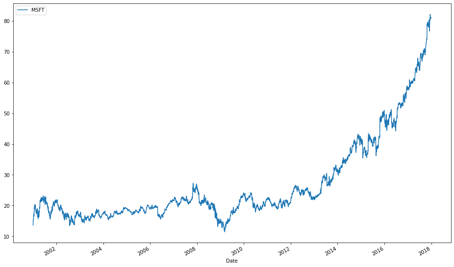

```python
Symbol1_prices = data['Adj Close'][Symbol1]
Symbol1_prices.name = Symbol1
Symbol1_prices.plot(figsize=(16,10))
plt.legend()
plt.show()
```

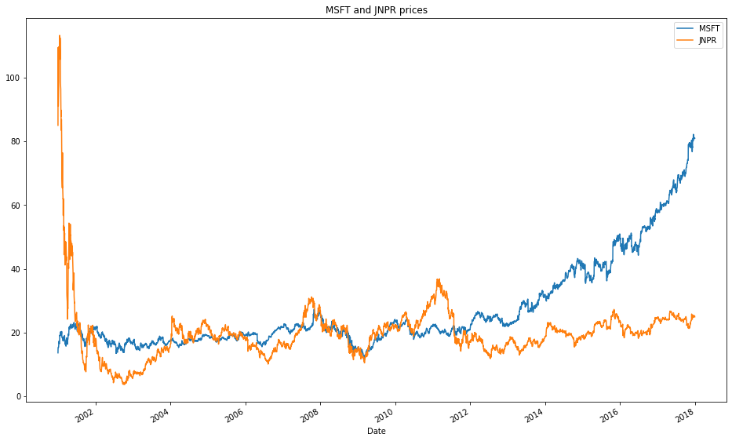

```python
Symbol2_prices = data['Adj Close'][Symbol2]
Symbol2_prices.name = Symbol2
plt.title(Symbol1 + " and " + Symbol2 + " prices")
Symbol1_prices.plot(figsize=(16,10))
Symbol2_prices.plot()
plt.legend()
plt.show()
```

```
1.0
```

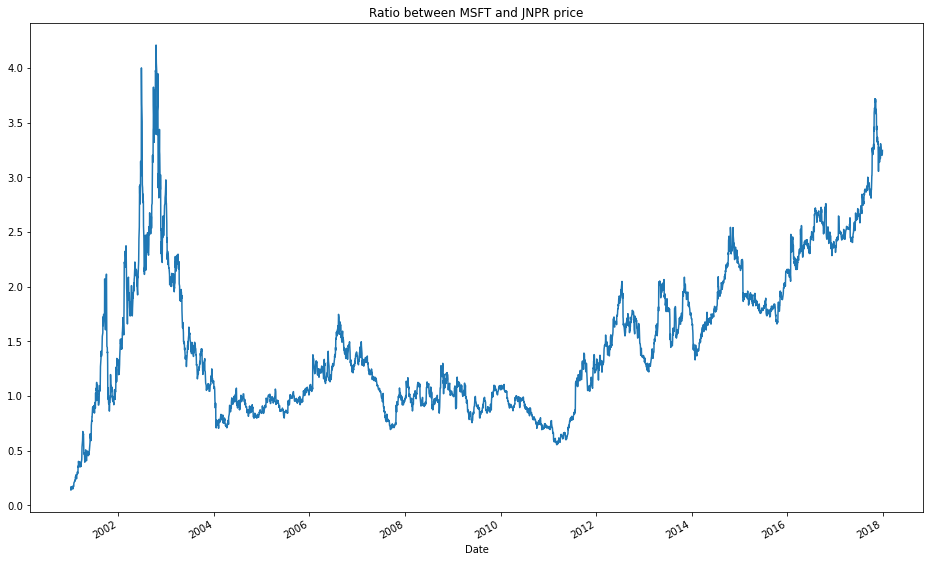

```python
score, pvalue, _ = coint(Symbol1_prices, Symbol2_prices)
print(pvalue)
ratios = Symbol1_prices / Symbol2_prices
plt.title("Ratio between " + Symbol1 + " and " + Symbol2 + " price")
ratios.plot(figsize=(16,10))
plt.show()
```

# Task 3 - Set up the Helper Functions for Modeling

```python
def zscore(series):
    return (series - series.mean()) / np.std(series)
```

# Task 4 - Build Model

```python
# Not applicable for this iteration of modeling
```

# Task 5 - Evaluate Model Performance

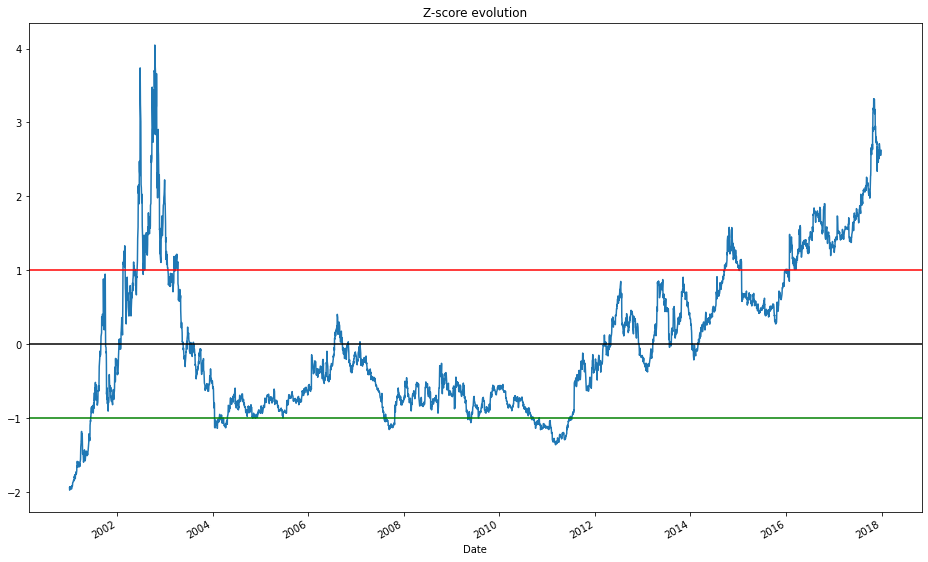

```python
zscore(ratios).plot(figsize=(16,10))
plt.title("Z-score evolution")
plt.axhline(zscore(ratios).mean(),color="black")
plt.axhline(1.0, color="red")
plt.axhline(-1.0, color="green")
plt.show()
```

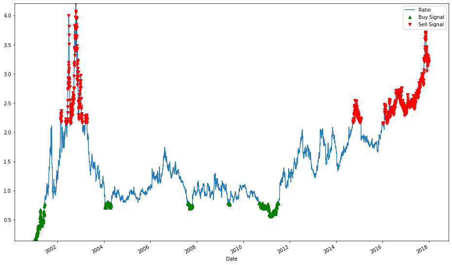

```python
ratios.plot(figsize=(16,10))
buy = ratios.copy()
sell = ratios.copy()
buy[zscore(ratios)>-1] = 0
sell[zscore(ratios)<1] = 0
buy.plot(color="g", linestyle="None", marker="^")
sell.plot(color="r", linestyle="None", marker="v")
x1,x2,y1,y2 = plt.axis()
plt.axis((x1,x2,ratios.min(),ratios.max()))
plt.legend(["Ratio", "Buy Signal", "Sell Signal"])
plt.show()
```

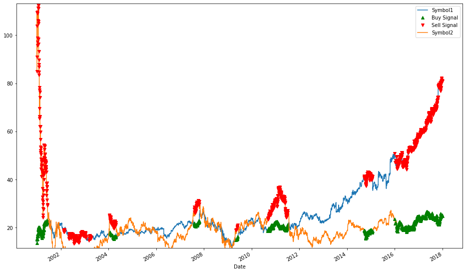

```python
symbol1_buy=Symbol1_prices.copy()
symbol1_sell=Symbol1_prices.copy()
symbol2_buy=Symbol2_prices.copy()
symbol2_sell=Symbol2_prices.copy()

Symbol1_prices.plot(figsize=(16,10))
symbol1_buy[zscore(ratios)>-1] = 0
symbol1_sell[zscore(ratios)<1] = 0
symbol1_buy.plot(color="g", linestyle="None", marker="^")
symbol1_sell.plot(color="r", linestyle="None", marker="v")

pair_correlation_trading_strategy = pd.DataFrame(index=Symbol1_prices.index)
pair_correlation_trading_strategy['symbol1_price']=Symbol1_prices
pair_correlation_trading_strategy['symbol1_buy']=np.zeros(len(Symbol1_prices))
pair_correlation_trading_strategy['symbol1_sell']=np.zeros(len(Symbol1_prices))
pair_correlation_trading_strategy['symbol2_buy']=np.zeros(len(Symbol1_prices))
pair_correlation_trading_strategy['symbol2_sell']=np.zeros(len(Symbol1_prices))

position=0
for i in range(len(Symbol1_prices)):
    s1price=Symbol1_prices[i]
    s2price=Symbol2_prices[i]
    if not position and symbol1_buy[i]!=0:
        pair_correlation_trading_strategy['symbol1_buy'][i]=s1price
        pair_correlation_trading_strategy['symbol2_sell'][i] = s2price
        position=1
    elif not position and symbol1_sell[i]!=0:
        pair_correlation_trading_strategy['symbol1_sell'][i] = s1price
        pair_correlation_trading_strategy['symbol2_buy'][i] = s2price
        position = -1
    elif position==-1 and (symbol1_sell[i]==0 or i==len(Symbol1_prices)-1):
        pair_correlation_trading_strategy['symbol1_buy'][i] = s1price
        pair_correlation_trading_strategy['symbol2_sell'][i] = s2price
        position = 0
    elif position==1 and (symbol1_buy[i] == 0 or i==len(Symbol1_prices)-1):
        pair_correlation_trading_strategy['symbol1_sell'][i] = s1price
        pair_correlation_trading_strategy['symbol2_buy'][i] = s2price
        position = 0

Symbol2_prices.plot()
symbol2_buy[zscore(ratios)<1] = 0
symbol2_sell[zscore(ratios)>-1] = 0
symbol2_buy.plot(color="g", linestyle="None", marker="^")
symbol2_sell.plot(color="r", linestyle="None", marker="v")

x1,x2,y1,y2 = plt.axis()
plt.axis((x1,x2,Symbol1_prices.min(),Symbol2_prices.max()))
plt.legend(["Symbol1", "Buy Signal", "Sell Signal","Symbol2"])
plt.show()
```

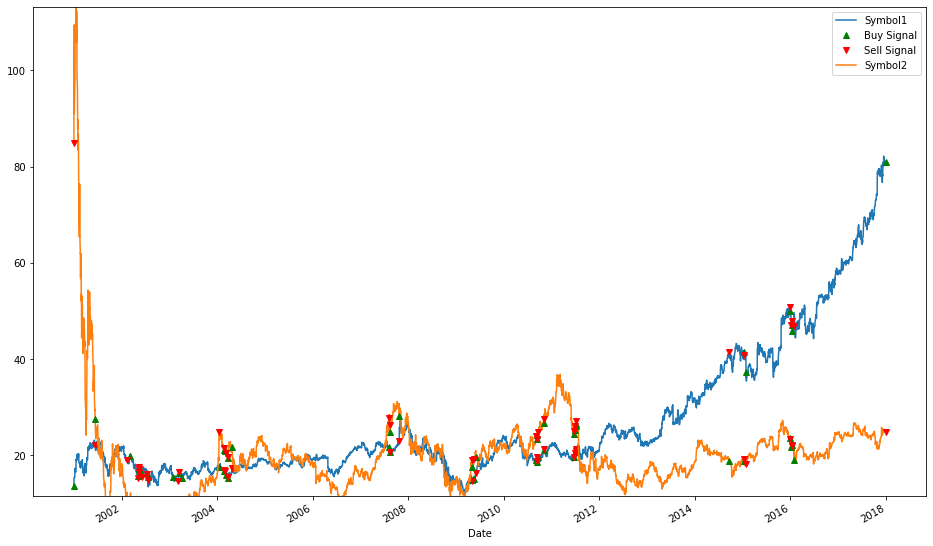

```python
Symbol1_prices.plot(figsize=(16,10))
pair_correlation_trading_strategy['symbol1_buy'].plot(color="g", linestyle="None", marker="^")
pair_correlation_trading_strategy['symbol1_sell'].plot(color="r", linestyle="None", marker="v")
Symbol2_prices.plot()
pair_correlation_trading_strategy['symbol2_buy'].plot(color="g", linestyle="None", marker="^")
pair_correlation_trading_strategy['symbol2_sell'].plot(color="r", linestyle="None", marker="v")
x1, x2, y1, y2 = plt.axis()
plt.axis((x1,x2,Symbol1_prices.min(),Symbol2_prices.max()))
plt.legend(["Symbol1", "Buy Signal", "Sell Signal","Symbol2"])
plt.show()
```

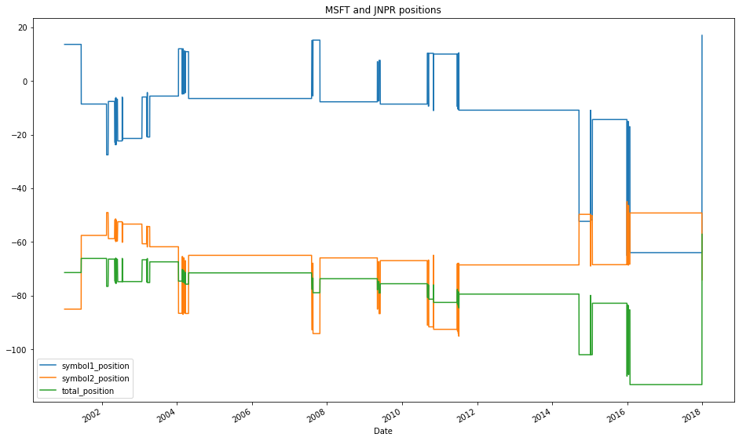

```python
pair_correlation_trading_strategy['symbol1_buy'].head()

pair_correlation_trading_strategy['symbol1_position']=\
pair_correlation_trading_strategy['symbol1_buy']-pair_correlation_trading_strategy['symbol1_sell']

pair_correlation_trading_strategy['symbol2_position']=\
pair_correlation_trading_strategy['symbol2_buy']-pair_correlation_trading_strategy['symbol2_sell']

pair_correlation_trading_strategy['symbol1_position'].cumsum().plot(figsize=(16,10))
pair_correlation_trading_strategy['symbol2_position'].cumsum().plot()

pair_correlation_trading_strategy['total_position']=\
pair_correlation_trading_strategy['symbol1_position']+pair_correlation_trading_strategy['symbol2_position']
pair_correlation_trading_strategy['total_position'].cumsum().plot()
plt.title(Symbol1 + " and " + Symbol2 + " positions")
plt.legend()
plt.show()
```

```python
pair_correlation_trading_strategy['symbol1_price']=Symbol1_prices
pair_correlation_trading_strategy['symbol1_buy']=np.zeros(len(Symbol1_prices))
pair_correlation_trading_strategy['symbol1_sell']=np.zeros(len(Symbol1_prices))
pair_correlation_trading_strategy['symbol2_buy']=np.zeros(len(Symbol1_prices))
pair_correlation_trading_strategy['symbol2_sell']=np.zeros(len(Symbol1_prices))
pair_correlation_trading_strategy['delta']=np.zeros(len(Symbol1_prices))

position=0
s1_shares = 1000000
for i in range(len(Symbol1_prices)):
    s1positions= Symbol1_prices[i] * s1_shares
    s2positions= Symbol2_prices[i] * int(s1positions/Symbol2_prices[i])
    print(Symbol1_prices[i],Symbol2_prices[i])
    delta_position=s1positions-s2positions
    if not position and symbol1_buy[i]!=0:
        pair_correlation_trading_strategy['symbol1_buy'][i]=s1positions
        pair_correlation_trading_strategy['symbol2_sell'][i] = s2positions
        pair_correlation_trading_strategy['delta'][i]=delta_position
        position=1
    elif not position and symbol1_sell[i]!=0:
        pair_correlation_trading_strategy['symbol1_sell'][i] = s1positions
        pair_correlation_trading_strategy['symbol2_buy'][i] = s2positions
        pair_correlation_trading_strategy['delta'][i] = delta_position
        position = -1
    elif position==-1 and (symbol1_sell[i]==0 or i==len(Symbol1_prices)-1):
        pair_correlation_trading_strategy['symbol1_buy'][i] = s1positions
        pair_correlation_trading_strategy['symbol2_sell'][i] = s2positions
        position = 0
    elif position==1 and (symbol1_buy[i] == 0 or i==len(Symbol1_prices)-1):
        pair_correlation_trading_strategy['symbol1_sell'][i] = s1positions
        pair_correlation_trading_strategy['symbol2_buy'][i] = s2positions
        position = 0
```

[output not shown]

[output cut: 4221 more lines]

[output not shown]

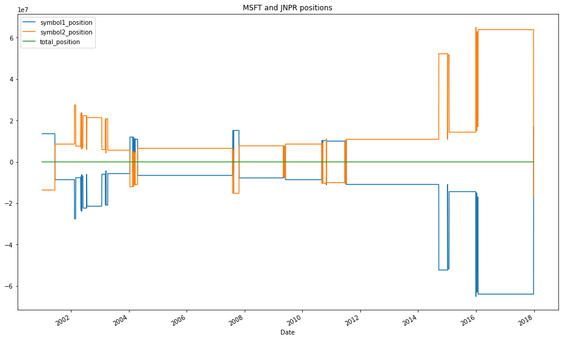

```python
pair_correlation_trading_strategy['symbol1_position']=\
pair_correlation_trading_strategy['symbol1_buy']-pair_correlation_trading_strategy['symbol1_sell']

pair_correlation_trading_strategy['symbol2_position']=\
pair_correlation_trading_strategy['symbol2_buy']-pair_correlation_trading_strategy['symbol2_sell']

pair_correlation_trading_strategy['symbol1_position'].cumsum().plot(figsize=(16,10))
pair_correlation_trading_strategy['symbol2_position'].cumsum().plot()

pair_correlation_trading_strategy['total_position']=\
pair_correlation_trading_strategy['symbol1_position']+pair_correlation_trading_strategy['symbol2_position']
pair_correlation_trading_strategy['total_position'].cumsum().plot()
plt.title(Symbol1 + " and " + Symbol2 + " positions")
plt.legend()
plt.show()
```

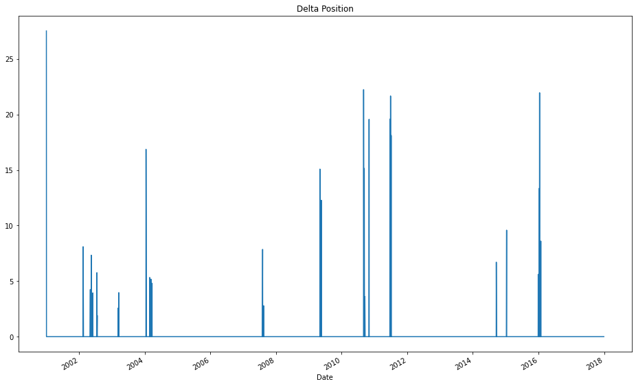

```python
pair_correlation_trading_strategy['delta'].plot(figsize=(16,10))
plt.title("Delta Position")
plt.show()
```